# The Naming Game: an Analysis on US Baby Name Data

Talyah Greyling

2025-06-19

### Abstract

This report is a concise analysis of baby naming trends in the US through the years utilising graphs, tables and bullet summaries to explain the findings to the client, a New York based kids’ toy design agency.

# 1 Introduction

This analysis examines US baby naming trends to identify which trends endure versus fade. It then explores how a cultural influence like popular movies can shape naming choices. For brevity and ease of use all findings are presented in bullet point summaries.

# 2 Persistence of baby names

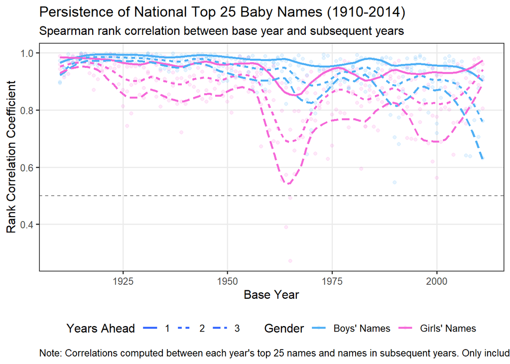

Figure 2.1: Persistence of National Top 25 Baby Names (1910-2014) by Spearman rank-correlation

Insights from Figure 1 (above): * Name persistence is much stronger among boys than girls. * Generally boy and girl names display downward sloping persistence trends over time. * Persistence becomes weaker for boys and girls the further the future year is from the target year. * The client’s suspicion on slower to persistence since the 1990s is: * Correct for boys names. * Incorrect for girls names which display with an unexpected upwards trend since the 1990s.

# 3 Popular Names

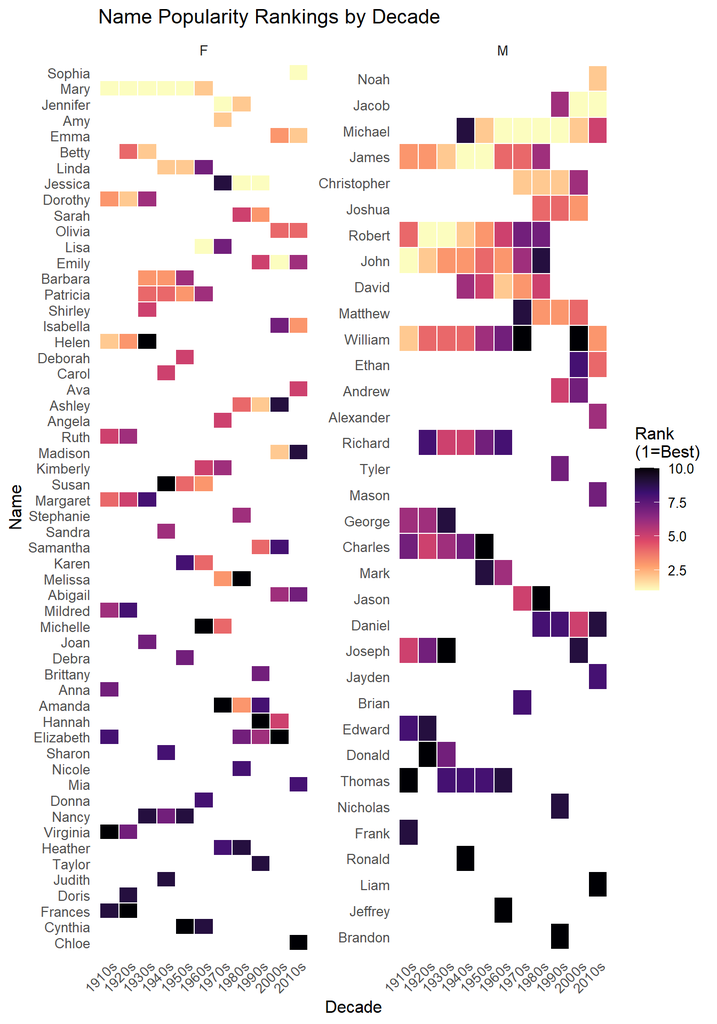

Figure 3.1: Most Popular Baby Names per decade (1910-2014)

Insights from Figure 2 (above): * Name persistence is much stronger among males. * Popularity is concentrated among less names for males, contributing to their higher persistence levels.  
* Most persistently popular name over all decades: * Girls: Mary * Boys: William * High popularity before the 1960s: * Girls: Nancy, Margaret, Helen, Patricia, Barbara, Mary * Boys: Thomas, Charles, Richard, William, John, Robert, James * High popularity after the 1960s: * Girls: Elizabeth, Amanda, Ashley, Emily * Boys: Daniel, Matthew, Joshua, Christopher, James, Michael

# 4 Movie star names calculations

```
## # A tibble: 29,118 × 7
##    name              Name     Surname  character   title release_year tmdb_score
##    <chr>             <chr>    <chr>    <chr>       <chr>        <dbl>      <dbl>
##  1 Judy Garland      Judy     Garland  Dorothy Ga… The …         1939        7.6
##  2 Ray Bolger        Ray      Bolger   Hunk / Sca… The …         1939        7.6
##  3 Jack Haley        Jack     Haley    Hickory / … The …         1939        7.6
##  4 Bert Lahr         Bert     Lahr     Zeke / Cow… The …         1939        7.6
##  5 Margaret Hamilton Margaret Hamilton Elmira Gul… The …         1939        7.6
##  6 Frank Morgan      Frank    Morgan   Professor … The …         1939        7.6
##  7 Clara Blandick    Clara    Blandick Auntie Em   The …         1939        7.6
##  8 Charley Grapewin  Charley  Grapewin Uncle Henry The …         1939        7.6
##  9 Billie Burke      Billie   Burke    Glinda      The …         1939        7.6
## 10 Pat Walshe        Pat      Walshe   Nikko       The …         1939        7.6
## # ℹ 29,108 more rows
```

Table 4.1: Top 10 Female Names Coinciding With Actor Names

| name | Name | Surname | character | title | release_year | tmdb_score | Decade | Gender | Total_Dec_Count | Rank |
| --- | --- | --- | --- | --- | --- | --- | --- | --- | --- | --- |
| Mary Astor | Mary | Astor | Brigid O’Shaughnessy | The Maltese Falcon | 1941 | 7.8 | 1940 | F | 639986 | 1 |
| Mary Anderson | Mary | Anderson | Maybelle Merriwether | Gone with the Wind | 1939 | 8.0 | 1940 | F | 639986 | 1 |
| Mary Nash | Mary | Nash | Margaret Lord | The Philadelphia Story | 1940 | 7.7 | 1940 | F | 639986 | 1 |
| Mary Clare | Mary | Clare | Baroness Isabel Nisatona | The Lady Vanishes | 1938 | 7.5 | 1940 | F | 639986 | 1 |
| Mary Wickes | Mary | Wickes | Dora Pickford | Now, Voyager | 1942 | 7.4 | 1940 | F | 639986 | 1 |
| Mary Morris | Mary | Morris | Halima | The Thief of Bagdad | 1940 | 7.2 | 1940 | F | 639986 | 1 |
| Mary Clare | Mary | Clare | Mrs. Corney | Oliver Twist | 1948 | 7.5 | 1940 | F | 639986 | 1 |
| Mary Boland | Mary | Boland | Mrs. Bennet | Pride and Prejudice | 1940 | 6.9 | 1940 | F | 639986 | 1 |
| Mary Jo Ellis | Mary | Jo Ellis | Clementine | The Barkleys of Broadway | 1949 | 7.0 | 1940 | F | 639986 | 1 |
| Mary Astor | Mary | Astor | Brigid O’Shaughnessy | The Maltese Falcon | 1941 | 7.8 | 1950 | F | 625498 | 1 |

Table 4.1: Top 10 Male Names Coinciding With Actor Names

| name | Name | Surname | character | title | release_year | tmdb_score | Decade | Gender | Total_Dec_Count | Rank |
| --- | --- | --- | --- | --- | --- | --- | --- | --- | --- | --- |
| James Burke | James | Burke | Luke | The Maltese Falcon | 1941 | 7.8 | 1950 | M | 843262 | 1 |
| James Whitmore | James | Whitmore | Gus Minissi | The Asphalt Jungle | 1950 | 7.5 | 1950 | M | 843262 | 1 |
| James Stewart | James | Stewart | Macaulay ‘Mike’ Connor | The Philadelphia Story | 1940 | 7.7 | 1950 | M | 843262 | 1 |
| James Flavin | James | Flavin | Mate Briggs | King Kong | 1933 | 7.6 | 1950 | M | 843262 | 1 |
| James McKechnie | James | McKechnie | Spud Wilson | The Life and Death of Colonel Blimp | 1943 | 7.6 | 1950 | M | 843262 | 1 |
| James Knight | James | Knight | Club Porter (1902) | The Life and Death of Colonel Blimp | 1943 | 7.6 | 1950 | M | 843262 | 1 |
| James Rennie | James | Rennie | Frank McIntyre | Now, Voyager | 1942 | 7.4 | 1950 | M | 843262 | 1 |
| James Cagney | James | Cagney | Tom Powers | The Public Enemy | 1931 | 7.3 | 1950 | M | 843262 | 1 |
| James Stephenson | James | Stephenson | Howard Joyce | The Letter | 1940 | 7.4 | 1950 | M | 843262 | 1 |
| James Carlisle | James | Carlisle | NA | The Letter | 1940 | 7.4 | 1950 | M | 843262 | 1 |

# 5 Do popular movies influence popular baby names?

## 5.1 Insights from Tables above:

- TMDB = The Movie Database: The percentage score for a movie or TV show is by database users on a 10-star scale.
- This analysis was less informative since the most popular baby names, Mary for females and James for males, that coincide with actor names were shown already be popular prior to the movie release dates when looking at the heat map.